# Final Project: WW2 Bombing Study

Final Project  
Data Science 1 with R (STAT 301-1)

Author

Oscar Baliga

Published

December 11, 2024

**Github Repo Link**

[Oscar’s Link](https://github.com/oscbal/final_project.git)

## Introduction to the Data

### Data Source

This dataset consists of digitized paper mission reports from World War II, developed by Lt Col Jenns Robertson of the US Air Force. The records include data from U.S. and Royal Air Force missions, as well as contributions from Australian, New Zealand, and South African air forces. The dataset captures a live-action sequence of air warfare from 1939 to 1945[^1]

<sup>1</sup> [Link to Dataset. Accessed on 11/05/24.](https://www.kaggle.com/datasets/usaf/world-war-ii?resource=download)

### Why This Data

As a double major in Data Science and History, I am fascinated by the intersection of these two fields. Analyzing historical data from significant events like World War II allows me to engage with history from a new perspective. The digitized mission reports provide opportunities to uncover patterns that traditional methods might overlook. I can investigate how factors such as altitude and aircraft type impacted mission outcomes. This approach not only enhances my understanding of military history but also develops my data analysis skills. Ultimately, I aim to provide new insights into World War II that can inform both academic and public discourse.

### Data Quality & Complexity Check

#### Data Overview:

| skim_type | skim_variable | n_missing | complete_rate | character.min | character.max | character.empty | character.n_unique | character.whitespace | numeric.mean | numeric.sd | numeric.p0 | numeric.p25 | numeric.p50 | numeric.p75 | numeric.p100 |
| --- | --- | --- | --- | --- | --- | --- | --- | --- | --- | --- | --- | --- | --- | --- | --- |
| character | Mission.Date | 0 | 1.0000000 | 8 | 10 | 0 | 1899 | 0 | NA | NA | NA | NA | NA | NA | NA |
| character | Theater.of.Operations | 3158 | 0.9822864 | 3 | 11 | 0 | 6 | 0 | NA | NA | NA | NA | NA | NA | NA |
| character | Country | 51787 | 0.7095204 | 3 | 13 | 0 | 5 | 0 | NA | NA | NA | NA | NA | NA | NA |
| character | Air.Force | 51837 | 0.7092399 | 3 | 8 | 0 | 17 | 0 | NA | NA | NA | NA | NA | NA | NA |
| character | Unit.ID | 127368 | 0.2855773 | 2 | 31 | 0 | 781 | 0 | NA | NA | NA | NA | NA | NA | NA |
| character | Aircraft.Series | 116 | 0.9993493 | 3 | 15 | 0 | 74 | 0 | NA | NA | NA | NA | NA | NA | NA |
| character | Callsign | 178260 | 0.0001178 | 4 | 9 | 0 | 12 | 0 | NA | NA | NA | NA | NA | NA | NA |
| character | Mission.Type | 131095 | 0.2646721 | 1 | 10 | 0 | 32 | 0 | NA | NA | NA | NA | NA | NA | NA |
| character | Takeoff.Base | 174898 | 0.0189757 | 1 | 30 | 0 | 132 | 0 | NA | NA | NA | NA | NA | NA | NA |
| character | Takeoff.Location | 174943 | 0.0187233 | 2 | 15 | 0 | 30 | 0 | NA | NA | NA | NA | NA | NA | NA |
| character | Takeoff.Latitude | 175300 | 0.0167208 | 4 | 12 | 0 | 95 | 0 | NA | NA | NA | NA | NA | NA | NA |
| character | Target.ID | 50875 | 0.7146359 | 1 | 23 | 0 | 4256 | 0 | NA | NA | NA | NA | NA | NA | NA |
| character | Target.Country | 599 | 0.9966401 | 4 | 32 | 0 | 90 | 0 | NA | NA | NA | NA | NA | NA | NA |
| character | Target.City | 2263 | 0.9873066 | 2 | 87 | 0 | 10085 | 0 | NA | NA | NA | NA | NA | NA | NA |
| character | Target.Type | 31911 | 0.8210073 | 2 | 65 | 0 | 2935 | 0 | NA | NA | NA | NA | NA | NA | NA |
| character | Target.Industry | 51802 | 0.7094362 | 5 | 121 | 0 | 55 | 0 | NA | NA | NA | NA | NA | NA | NA |
| character | Target.Priority | 43561 | 0.7556610 | 1 | 4 | 0 | 15 | 0 | NA | NA | NA | NA | NA | NA | NA |
| character | High.Explosives.Type | 136336 | 0.2352747 | 1 | 44 | 0 | 40 | 0 | NA | NA | NA | NA | NA | NA | NA |
| character | High.Explosives.Weight..Pounds. | 176260 | 0.0113360 | 1 | 22 | 0 | 224 | 0 | NA | NA | NA | NA | NA | NA | NA |
| character | Incendiary.Devices.Type | 172762 | 0.0309567 | 1 | 39 | 0 | 43 | 0 | NA | NA | NA | NA | NA | NA | NA |
| character | Fragmentation.Devices.Type | 172516 | 0.0323366 | 1 | 39 | 0 | 23 | 0 | NA | NA | NA | NA | NA | NA | NA |
| character | Time.Over.Target | 177592 | 0.0038647 | 1 | 8 | 0 | 366 | 0 | NA | NA | NA | NA | NA | NA | NA |
| character | Bomb.Damage.Assessment | 178177 | 0.0005833 | 4 | 109 | 0 | 64 | 0 | NA | NA | NA | NA | NA | NA | NA |
| numeric | Mission.ID | 0 | 1.0000000 | NA | NA | NA | NA | NA | 8.941455e+04 | 5.164974e+04 | 1.00000 | 44571.00 | 89540.00000 | 134171.00000 | 178742.00 |
| numeric | Takeoff.Longitude | 175301 | 0.0167152 | NA | NA | NA | NA | NA | 2.206186e+02 | 4.540470e+02 | -177.32861 | 14.40 | 29.85139 | 96.13322 | 1355.00 |
| numeric | Target.Latitude | 8716 | 0.9511109 | NA | NA | NA | NA | NA | 3.806779e+01 | 1.871140e+01 | -37.41667 | 26.25 | 47.50000 | 50.93000 | 1108.00 |
| numeric | Target.Longitude | 8738 | 0.9509875 | NA | NA | NA | NA | NA | 4.334021e+01 | 5.968116e+01 | -179.45129 | 7.62 | 11.33000 | 97.40000 | 1000.65 |
| numeric | Altitude..Hundreds.of.Feet. | 57455 | 0.6777279 | NA | NA | NA | NA | NA | 1.390268e+02 | 1.868183e+02 | 0.00000 | 70.00 | 122.00000 | 223.00000 | 40000.00 |
| numeric | Airborne.Aircraft | 96039 | 0.4613055 | NA | NA | NA | NA | NA | 1.232977e+01 | 1.251483e+01 | 0.00000 | 2.00 | 11.00000 | 17.00000 | 332.00 |
| numeric | Attacking.Aircraft | 53173 | 0.7017461 | NA | NA | NA | NA | NA | 1.021890e+01 | 1.124640e+01 | 0.00000 | 2.00 | 7.00000 | 12.00000 | 332.00 |
| numeric | Bombing.Aircraft | 96669 | 0.4577717 | NA | NA | NA | NA | NA | 1.234749e+01 | 1.257355e+01 | 0.00000 | 2.00 | 11.00000 | 18.00000 | 332.00 |
| numeric | Aircraft.Returned | 178148 | 0.0007460 | NA | NA | NA | NA | NA | 2.157895e+00 | 1.369816e+00 | 1.00000 | 1.00 | 2.00000 | 3.00000 | 7.00 |
| numeric | Aircraft.Failed | 178034 | 0.0013855 | NA | NA | NA | NA | NA | 4.275304e+00 | 5.924758e+00 | 1.00000 | 1.00 | 2.00000 | 4.00000 | 48.00 |
| numeric | Aircraft.Damaged | 178243 | 0.0002131 | NA | NA | NA | NA | NA | 2.052632e+00 | 1.675699e+00 | 0.00000 | 1.00 | 1.50000 | 2.75000 | 9.00 |
| numeric | Aircraft.Lost | 178123 | 0.0008862 | NA | NA | NA | NA | NA | 2.279253e+00 | 6.414377e+00 | 0.00000 | 1.00 | 1.00000 | 2.00000 | 80.00 |
| numeric | High.Explosives | 143544 | 0.1948441 | NA | NA | NA | NA | NA | 3.333121e+01 | 1.053565e+02 | 0.00000 | 8.00 | 16.00000 | 36.00000 | 10000.00 |
| numeric | High.Explosives.Weight..Tons. | 32080 | 0.8200593 | NA | NA | NA | NA | NA | 2.391200e+01 | 9.009202e+01 | 0.00000 | 2.00 | 9.00000 | 30.00000 | 20000.00 |
| numeric | Incendiary.Devices | 174998 | 0.0184147 | NA | NA | NA | NA | NA | 1.320020e+02 | 4.985968e+02 | 0.00000 | 7.00 | 14.00000 | 32.00000 | 4875.00 |
| numeric | Incendiary.Devices.Weight..Pounds. | 177925 | 0.0019968 | NA | NA | NA | NA | NA | 1.996273e+04 | 4.533171e+04 | 0.00000 | 218.75 | 2640.00000 | 12500.00000 | 420000.00 |
| numeric | Incendiary.Devices.Weight..Tons. | 152549 | 0.1443339 | NA | NA | NA | NA | NA | 2.152721e+01 | 6.669264e+01 | 0.00000 | 1.00 | 6.00000 | 18.00000 | 999.00 |
| numeric | Fragmentation.Devices | 172513 | 0.0323534 | NA | NA | NA | NA | NA | 1.026846e+02 | 1.589417e+02 | 0.00000 | 10.00 | 38.46154 | 133.33333 | 3000.00 |
| numeric | Fragmentation.Devices.Weight..Pounds. | 178087 | 0.0010882 | NA | NA | NA | NA | NA | 2.065631e+03 | 2.424139e+03 | 0.00000 | 598.40 | 1500.00000 | 2400.00000 | 20640.00 |
| numeric | Fragmentation.Devices.Weight..Tons. | 161379 | 0.0948054 | NA | NA | NA | NA | NA | 1.201714e+01 | 2.722141e+01 | 0.00000 | 1.00 | 3.00000 | 12.00000 | 900.00 |
| numeric | Total.Weight..Pounds. | 176162 | 0.0118857 | NA | NA | NA | NA | NA | 1.237718e+04 | 2.064155e+05 | 0.00000 | 2100.00 | 5200.00000 | 10800.00000 | 9500000.00 |
| numeric | Total.Weight..Tons. | 11773 | 0.9339638 | NA | NA | NA | NA | NA | 2.576033e+01 | 9.064388e+01 | 0.00000 | 2.00 | 9.29000 | 31.00000 | 20000.00 |
| numeric | Source.ID | 4045 | 0.9773111 | NA | NA | NA | NA | NA | 1.526709e+05 | 1.055448e+05 | 1.00000 | 53476.50 | 167604.50000 | 211284.25000 | 699625.00 |

Much of the data has serious issues with non completeness. The most important variables, Target.Longitude and Target.Latitude, are nearly all complete, but for investigations into more minute details of bombing operations issues will be experienced with a lack of complete data. This missingness may occur due to biases in the data, such as differences in record keeping between air forces and theaters of combat, which mean conclusions drawn from them might pose an incorrect image of what is truly occurring. Overall with all of the variables, there is a lot of valuable information to parse through whcih will give interesting and sizable takeaways about the Allied air effort in World War 2.

- **Outliers**: There are many outliers for most numerical variables in the dataset:

```
    Takeoff Longitude: 429 outliers
```

```
Target Latitude: 145 outliers
```

```
Target Longitude: 127 outliers
```

```
Altitude Hundreds of Feet: 29
```

```
Airborne Aircraft: 1823
```

```
Attacking Aircraft: 9601
```

```
Bombing Aircraft: 1417
```

```
Aircraft Returned: 2
```

```
Aircraft Failed: 32
```

```
Aircraft Damaged: 2
```

```
Aircraft Lost: 18
```

```
High Explosives: 3537
```

```
High Explosives Weight Tons: 7568
```

```
Incendiary Devices: 515
```

```
Incendiary Devices Weight Pounds: 69
```

```
Incendiary Devices Weight Tons: 2081
```

```
Fragmentation Devices: 457
```

```
Fragmentation Devices Weight Pounds: 14
```

```
Fragmentation Devices Weight Tons: 2284
```

```
Total Weight Pounds: 136
```

```
Total Weight Tons: 9363
```

- **Bias in Data Collection**: The dataset may reflect biases based on the documentation practices of the time or the focus on certain operations over others. Furthermore, many record of this age may have been lost/damaged during combat or during the period between the end of WW2 and digitization of the dataset.

### Misc

The dataset offers a unique opportunity to understand the operational history of air forces during WWII. It serves not only as a historical record but also as a potential source for analyzing broader themes such as technological advancements in warfare and international military collaboration.

## Reasearch

### Guiding Question:

How did allied bombing operations differ between different time periods, air forces, theaters, and tactical strategies?

### Overarall Distribution of Bombing activities during the War

This map showcases the cumulative bombing damage wrought upon the Axis Powers by observing the locations bombed by various Allied air forces. The dots vary in size by the weight of bombs dropped and vary in color by which country the attack belonged to.

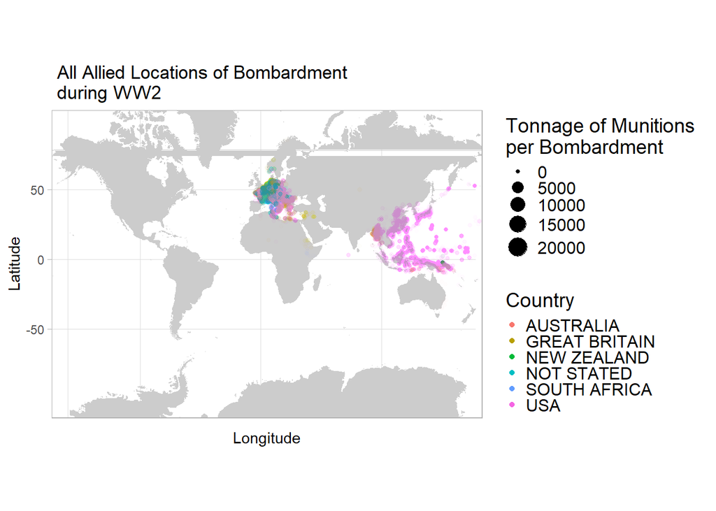

### All Locations of departure for Allied Aircaft

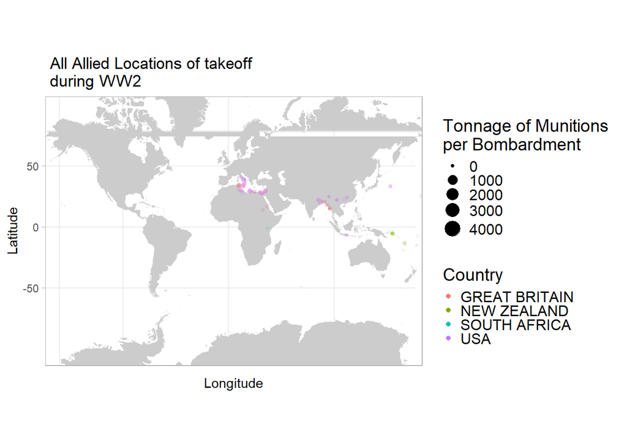

This graph shows where Allied bombers took off during WW2, broken down by country and the tonnage of munitions. The missingness rate is extremely high, which makes it hard to take the data at face value. That said, the points that are included probably line up with areas where the battle lines were really fluid, like North Africa or Southeast Asia, so they were more likely to be recorded. Places like England, which were more stable but integral for bombing Germany and Western Europe, might not show up here because of how the data was collected. The bases near the frontlines or major targets probably got more attention in the records since they were so important for operations. Bottom line: this shows some interesting patterns, but the missing data makes it tricky to draw any solid conclusions.

### Number of Bombardements by Country

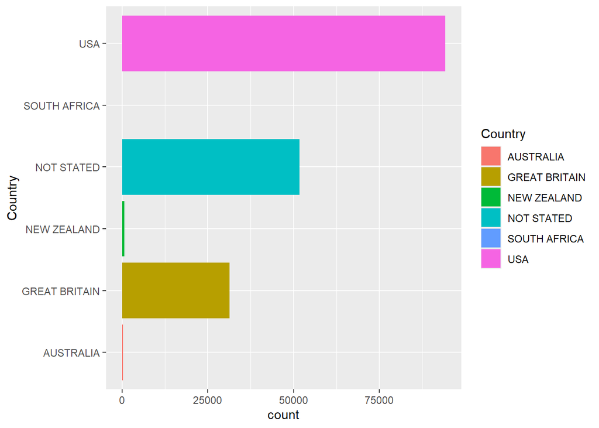

To answer the earlier questions raised of the ratio of bombardments by country, this graph shows that the US is by far in the lead. Interestingly, “Not Stated” is second by a wide margin to the UK. This likely means that many of the “Not Stated” bombardments were carried through by the Royal Air Force and may not have been documented due to the UK being to only nation fighting for a period of time or the international aspects of the British Armed services from the Commonwealth or exiled governments in the UK and using RAF resources.

### Bombardments by Country Over Time

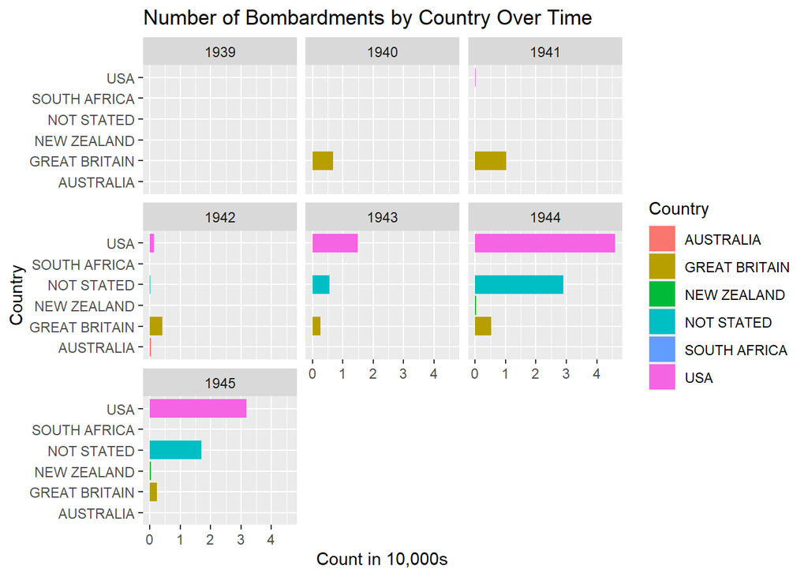

In these graphs we can observe the number of bombardments by country. Based upon the graph, the earlier claim that the “Not Stated” bombers were predominantly British is likely incorrect. Early in the war when the UK was the only Allied Power, there were no “Not Stated” values for countries, but, when America enters the war, the number of “USA” bombardments grows at the same rate as the “Not Stated” bombardments. This correlation in rate of growth is a strong sign that many of the “Not Stated” bombardments are predominantly American, not British.

### Aircraft Used By Year

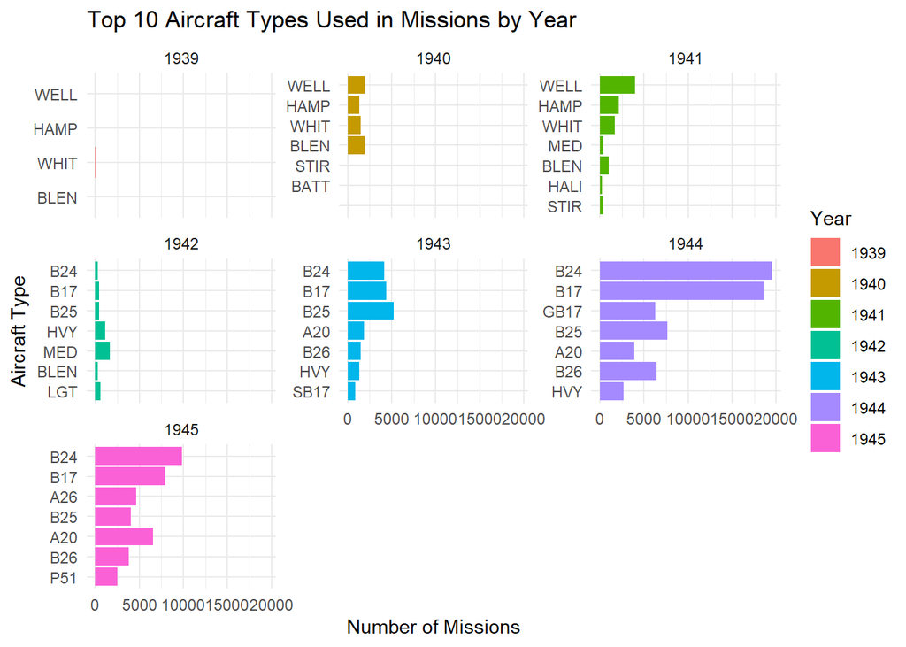

### Aircraft Losses

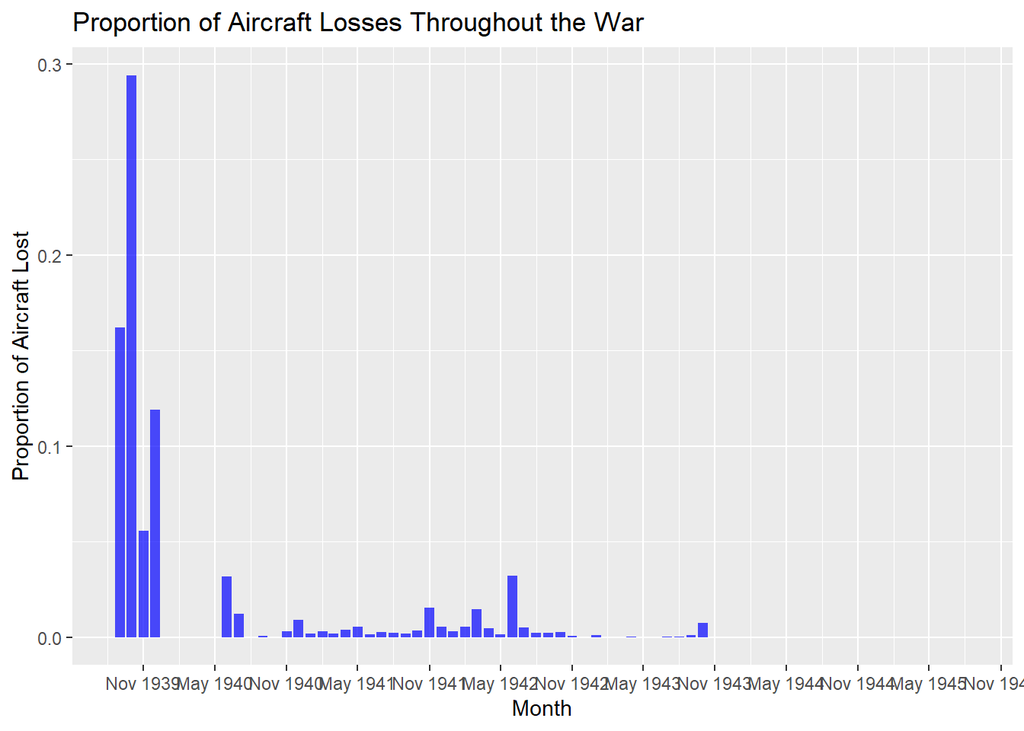

Here we can see an extremely cutoff from high loss percentages early in the war to a comparatively low stabilization later in the war. This can partially be explained by inaccuracies in the data set. Because it was early in the war, strict data keeping methods may not have been in place. On the other hand, aircraft losses were extremely high early in the war. The German air force, the Luftwaffe, was far superior to the Allied air forces, and they used this superiority to inflict heavy losses. During the German Blitzkrieg of Poland, almost the entire Polish Air Force was decimated. This could explain the high proportion of aircraft lost seen in the Fall of ’39. The next peak at May ’40 is likely the German lightning attack upon Northern France. The RAF was pushed to its limits in the following months in the desperate fight to save France and the Battle of Britain. The spike in May ’42 aligns with the dates of the Battle of Midway where intense combat took place over the island and the many aircraft carriers. Famously, Torpedo Squadron 8 (VT-8) lost 45 of its 48 men during the Battle of Midway which it just an example of the high casualties of the time.

### Most Popular Callsigns

| x |
| --- |
| GRAY |
| JOYCE |
| BOWER |
| BRERETON |
| JONES |
| LAWSON |
| DOOLITTLE |
| GREENING |
| HILGER |

Names:

This list of callsigns, like Doolittle, Greening, and Hilger, points to some of the most important figures and missions from WWII, like the Doolittle Raid on Japan. With a completion rate of just 0.0001178, it’s clear the dataset only captured the most famous callsigns tied to big operations, leaving out most of the missions and people involved.

### Time Over Target Investigation

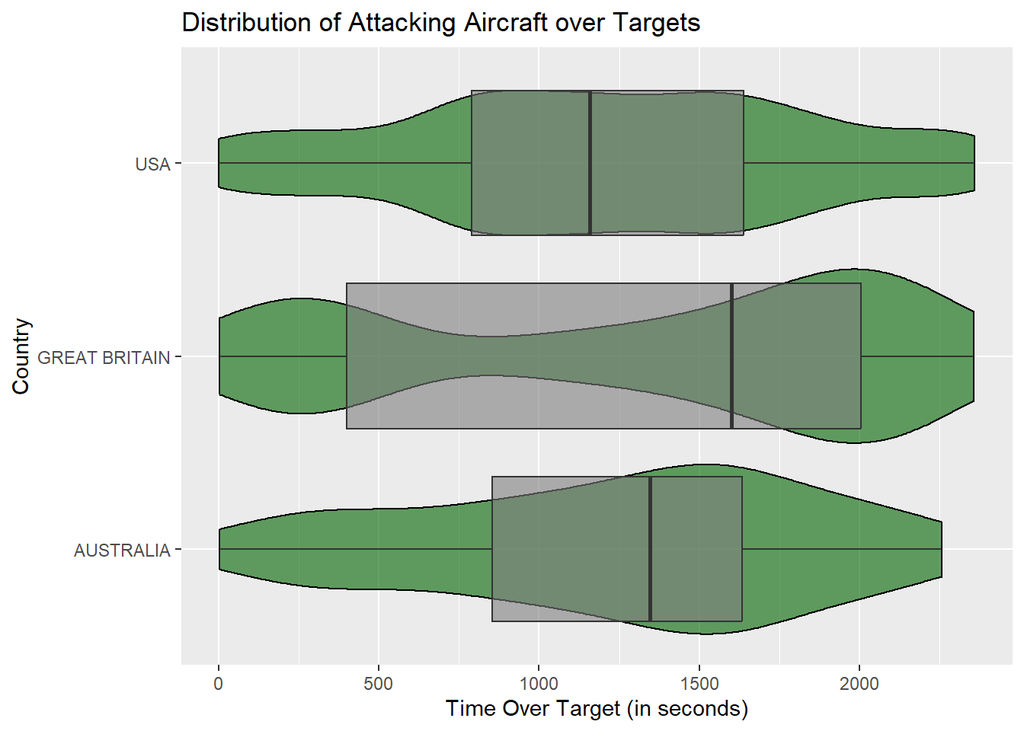

###### Western Theater:

| x |
| --- |
| CITIES TOWNS AND URBAN AREAS |
| AIR FIELDS AND AIRDROMES |
| “RR INSTALLATIONS, TRACKS, MARSHALLING YARDS, AND STATIONS” |
| UNIDENTIFIED TARGETS |
| BRIDGES |
| TACTICAL TARGETS: (UNIDENTIFIED OR NOT LISTED BELOW) |
| PORTS AND HARBORS |
| GUN EMPLACEMENTS |
| SYNTHETIC OIL REFINERIES |

###### Eastern Theater:

| x |
| --- |

Here we can see a stark difference in the record keeping between the Eastern and Western Theaters of combat. In the West, Industry targeting data was kept very well, even if it was a civilian target, while in the East target industry was not noted. This difference could be for various reasons, but it was likely not due to Air forces not strategically targeting different industries in the Eastern Theater because that would be a very large strategical oversight.

### Closer Look at Germany

#### Germany Overall

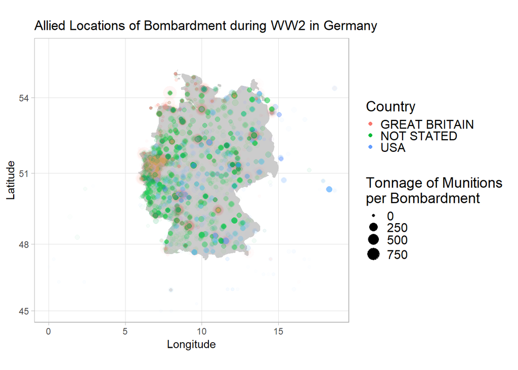

In this graph we can observe the distribution of bombing attacks across Germany. From the faint dots to the East of modern Germany, we can see areas that once were within the legal boundaries of Germany during this time but were removed post-war. We can also observe the focus on the industrial sector in the Ruhr Valley where many coal plants were located.

#### Looking at Berlin

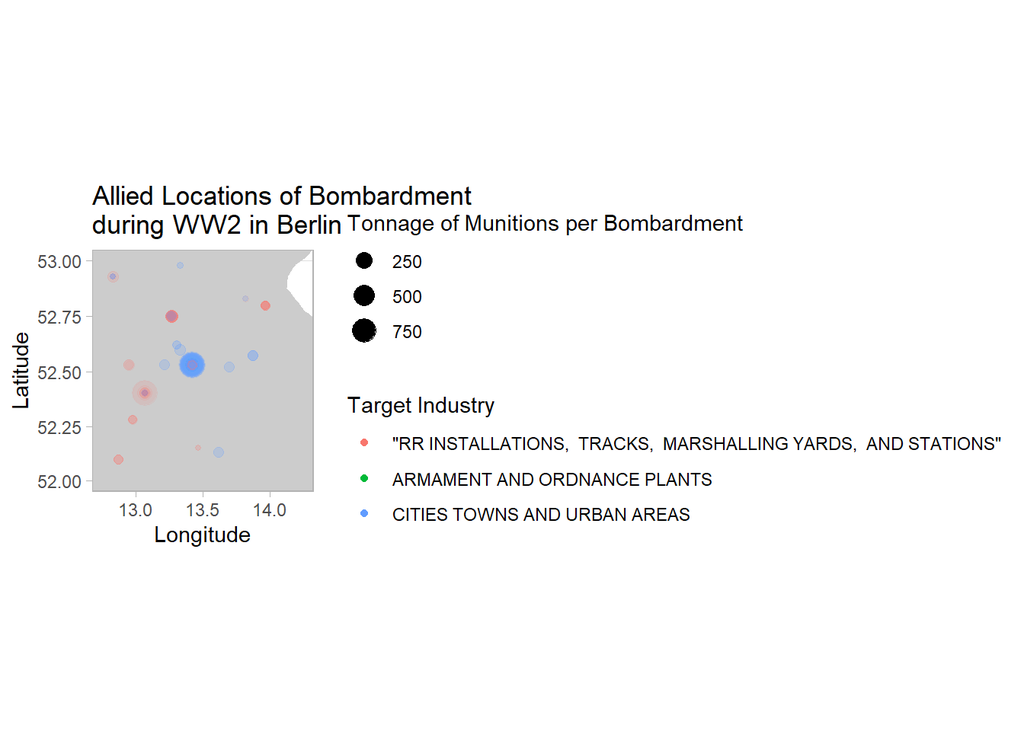

### Closer look at Japan

#### Japan Overall

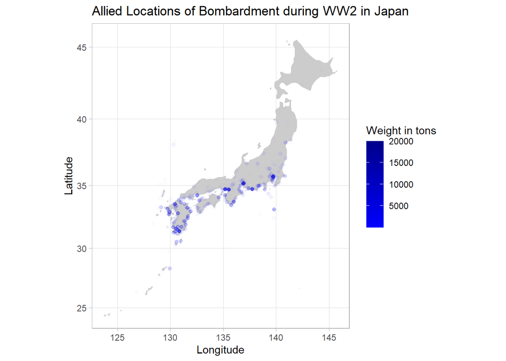

#### Bombs falling on Japan over time

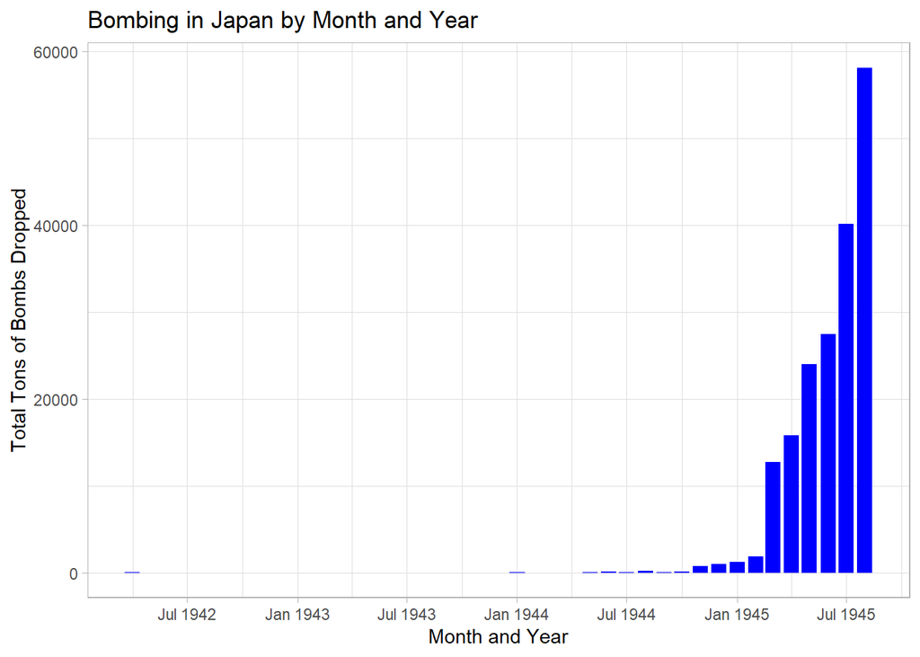

## Conclusion

From these graphs, maps, and tables we can take away various conclusions about the Allied bombing campaign upon the Axis Powers. Temporally, we can observe a large transition from Allied weakness to dominance. From the proportion of planes lost, we see extremely high proportions at the start of the war, but it decreases as time goes on. Part of the transition can be explained by the entrance of the United States into the war. As an the most industrialized country at that time, aircraft production skyrocketed. We can see this in the increase in aircraft missions over time and the change in the most popular aircraft.

One key missing aspect of the dataset is detailed data for the Eastern Theater. For attacks upon Japan, must less information was kept on industry targets and more. This is likely an issue with the dataset and not the actual strategic policy of the time. Looking at the map of Bombed locations on Japan, many coorelated with key urban and industrial areas.

Interesting aspect brought up during the inquiry were the most popular callsigns. Many famous pilots were written down, but they lack call sign for the bulk of all missions. This is an issue that plagued many of my investigations, but it also speaks volumes to the record keeping of the time.

The Second World War was part of a new development in strategic bombing, and it can be witnessed through Industries targeted and the connection between the ground war and the war in the air. The increase in mission numbers and new developments in technology speaks volumes to the power of war behind human progress. Although the bombing campaign paid a terrible price up the civilians and militaries of the world, it’s important to realize how monumental this time period was for the development of modern technology.

Overall, the most powerful convulsion drawn from this is the scope of the war. Witnessing the number of missions done and the weight of all bombs drops speaks volumes to the commitment and investment required to win a war of this scale. As the air war only represents just a small part of the Second World War, making graphs like these truly puts into scope how much had to be done to defeat these countries. Seeing how precariously the Allied Powers were early in the war, especially the UK, is truly important for understanding how difficult changed the tides must’ve been.